# 6. 데이터 분석 3차 - 모델링 및 평가

이번 분석에 사용할 분류 알고리즘은 xgboost로, 의사결정나무를 기반으로 하여 앙상블, 부스팅기법을 적용시킨 알고리즘이다. xgboost를 선택한 이유는 다음과 같다.

- 대중적으로 널리 쓰이며, 현존하는 머신러닝 알고리즘 중 가장 성능이 뛰어나다고 평가받음
- 의사결정나무 기반으로, 모델의 해석이 용이함

이번엔 2차 분석과정의 PCA결과를 그대로 활용할 예정이므로, 전처리 과정 없이 알고리즘만 바꾸어 진행하도록 한다.

```python
import pandas as pd
import numpy as np
import matplotlib.pyplot as plt
import seaborn as sns
# 경고메세지 무시
import warnings
warnings.filterwarnings('ignore')
```

```python
# # 모든 행 출력
# pd.set_option('display.max_rows',None)
```

```python
import pickle
with open("labeledData.pickle","rb") as fr:
    labeledData = pickle.load(fr)
labeledData.head()
```

|  | top_pc1 | top_pc2 | top_pc3 | top_pc4 | jgl_pc1 | jgl_pc2 | jgl_pc3 | jgl_pc4 | jgl_pc5 | mid_pc1 | ... | mid_pc3 | mid_pc4 | bot_pc1 | bot_pc2 | bot_pc3 | sup_pc1 | sup_pc2 | sup_pc3 | sup_pc4 | sup_pc5 |
| --- | --- | --- | --- | --- | --- | --- | --- | --- | --- | --- | --- | --- | --- | --- | --- | --- | --- | --- | --- | --- | --- |
| 0 | 0.270250 | -0.914586 | -0.267005 | 0.119163 | 0.084020 | -0.118592 | -0.628261 | -0.217910 | -0.197148 | -0.232805 | ... | 0.063497 | 1.201486 | -0.006609 | -0.513175 | -0.503054 | 0.398597 | -1.548296 | -0.647546 | -0.398336 | 0.698654 |
| 1 | 0.279927 | -0.314131 | 0.705320 | -1.301689 | 0.065142 | -0.726905 | -1.034056 | 0.076725 | -0.099828 | 1.314067 | ... | -0.585552 | -0.046424 | 0.059728 | 0.342432 | 0.836099 | -0.877707 | 0.274677 | 0.342761 | -0.057358 | -0.145070 |
| 2 | 0.687933 | -0.746682 | -0.265716 | 0.627154 | -0.161862 | 0.007579 | -0.560032 | -0.469986 | 0.097852 | -0.305748 | ... | 0.170739 | 0.062447 | -0.076940 | -0.123363 | -0.378755 | -0.877707 | 0.274677 | 0.342761 | -0.057358 | -0.145070 |
| 3 | 0.806792 | -1.272499 | -0.670444 | 0.052987 | -0.342787 | -0.097301 | 1.944184 | 1.275426 | -0.002226 | 0.091925 | ... | 0.161387 | 0.262361 | -0.145374 | -0.221360 | -0.157697 | -0.595760 | -0.083321 | 0.984281 | -0.170991 | 0.043125 |
| 4 | -1.021076 | 1.506393 | 0.432076 | 0.563677 | 0.178768 | -0.587934 | -0.738529 | 0.866534 | -0.574271 | -0.762267 | ... | 0.083833 | 0.500766 | 0.015991 | -0.247132 | -0.385745 | 0.398597 | -1.548296 | -0.647546 | -0.398336 | 0.698654 |

5 rows × 21 columns

```python
# reshape
# 두 행이 하나의 입력변수이기 때문에, 두 행을 하나의 행렬로 묶어줌
data_x = labeledData.values.reshape(108504,2,21)
```

```python
# 무조건 패배한 팀이 첫행, 승리한 팀이 두번째행
data_x[:5], len(data_x)
```

```
(array([[[ 0.27024963, -0.91458572, -0.26700473,  0.11916252,
           0.08401962, -0.11859153, -0.62826146, -0.21790969,
          -0.19714751, -0.23280454,  0.33861672,  0.06349731,
           1.20148627, -0.00660863, -0.51317472, -0.50305385,
           0.39859715, -1.54829601, -0.64754634, -0.39833645,
           0.69865406],
         [ 0.27992695, -0.31413089,  0.70532046, -1.30168912,
           0.0651422 , -0.72690519, -1.03405648,  0.0767251 ,
          -0.0998281 ,  1.31406729, -2.024255  , -0.5855516 ,
          -0.04642384,  0.05972758,  0.34243162,  0.83609886,
          -0.87770659,  0.27467734,  0.34276087, -0.0573582 ,
          -0.14507025]]),
    ...
    (중략)
    ...
 108504)
```

```python
# 입력변수를 반으로 나눔
data_x1=data_x[:54252]
len(data_x1)
```

```
54252
```

```python
data_x2=data_x[54252:]
len(data_x2)
```

```
54252
```

```python
x2 = data_x2[:,::-1,:] #  각 매치별 > 팀별 > 포지션별 구조이므로, 팀 순서를 역순으로
```

```python
len(x2),len(data_x1)
```

```
(54252, 54252)
```

```python
# x값 하나의 리스트로
data_x = np.append(data_x1,x2,axis=0)
```

```python
# reshape
data_x = labeledData.values.reshape(108504,42) # 승리팀과 패배팀의 데이터를 한 행으로
data_x[:5]
```

```
array([[ 0.27024963, -0.91458572, -0.26700473,  0.11916252,  0.08401962,
        -0.11859153, -0.62826146, -0.21790969, -0.19714751, -0.23280454,
         0.33861672,  0.06349731,  1.20148627, -0.00660863, -0.51317472,
        -0.50305385,  0.39859715, -1.54829601, -0.64754634, -0.39833645,
         0.69865406,  0.27992695, -0.31413089,  0.70532046, -1.30168912,
         0.0651422 , -0.72690519, -1.03405648,  0.0767251 , -0.0998281 ,
         1.31406729, -2.024255  , -0.5855516 , -0.04642384,  0.05972758,
         0.34243162,  0.83609886, -0.87770659,  0.27467734,  0.34276087,
        -0.0573582 , -0.14507025]
    ...
    (생략)
    ...
    )
```

```python
# 목적변수 설정
data_y1 = np.array([0]*54252)
data_y2 = np.array([1]*54252)
```

```python
len(data_y1),len(data_y2)
```

```
(54252, 54252)
```

```python
data_y = np.append(data_y1,data_y2,axis=0)
```

```python
len(data_x),len(data_y) # 데이터 길이 재확인
```

```
(108504, 108504)
```

```python
# 컬럼명과 같이 확인하기 위해 DataFrame으로 재구성
columns = np.append('t1_' + labeledData.columns, 't2_' + labeledData.columns)
columns
```

```
array(['t1_top_pc1', 't1_top_pc2', 't1_top_pc3', 't1_top_pc4',
       't1_jgl_pc1', 't1_jgl_pc2', 't1_jgl_pc3', 't1_jgl_pc4',
       't1_jgl_pc5', 't1_mid_pc1', 't1_mid_pc2', 't1_mid_pc3',
       't1_mid_pc4', 't1_bot_pc1', 't1_bot_pc2', 't1_bot_pc3',
       't1_sup_pc1', 't1_sup_pc2', 't1_sup_pc3', 't1_sup_pc4',
       't1_sup_pc5', 't2_top_pc1', 't2_top_pc2', 't2_top_pc3',
       't2_top_pc4', 't2_jgl_pc1', 't2_jgl_pc2', 't2_jgl_pc3',
       't2_jgl_pc4', 't2_jgl_pc5', 't2_mid_pc1', 't2_mid_pc2',
       't2_mid_pc3', 't2_mid_pc4', 't2_bot_pc1', 't2_bot_pc2',
       't2_bot_pc3', 't2_sup_pc1', 't2_sup_pc2', 't2_sup_pc3',
       't2_sup_pc4', 't2_sup_pc5'], dtype=object)
```

```python
data_x = pd.DataFrame(data_x, columns=columns)
```

```python
# 훈련용 데이터와 검증용 데이터 분리
from sklearn.model_selection import train_test_split
train_x, valid_x, train_y, valid_y = train_test_split(data_x, data_y, random_state=8)
```

```python
train_x.shape, valid_x.shape, train_y.shape, valid_y.shape # 분리 결과 확인
```

```
((81378, 42), (27126, 42), (81378,), (27126,))
```

### xgboost

#### 핵심 파라미터

- n_estimators: 의사결정나무 갯수
- max_depth: 최대 깊이, 너무 크면 과적합 리스크
- eta: 학습률, 일반적으로 0.01~0.2
- tree_method: 데이터 분할 기준

```python
# xgboost
from xgboost import XGBClassifier
model = XGBClassifier(n_estimators=1000, max_depth=5, tree_method='approx',eta='0.2')
# early_stopping 적용
model.fit(train_x, train_y, early_stopping_rounds=100,
          eval_metric='error', eval_set=[(valid_x, valid_y)])

pred = model.predict(valid_x) # 검증 데이터로 예측한 결과
(pred == valid_y).mean()  # 정확도(accuracy)
```

```
...
(중략)
...
```

```
0.7126741871267419
```

```python
# 모델 저장
with open("model.pickle","wb") as fw:
    pickle.dump(model, fw)
```

정확도: 71.3%, 트리갯수: 113개

특별한 파라미터 튜닝 없이 파라미터에 적당한 임의의 값을 부여한 후 학습시킨 결과 이전 모델들에 비해 꽤나 유의미한 정확도의 향상을 확인하였다. 이에 적합한 파라미터로 모델을 튜닝하기 위해 그리드서치를 시도하였다.

```python
from sklearn.model_selection import GridSearchCV
```

```python
# 객체 생성, 일단은 트리 100개만 만듦
model = XGBClassifier(n_estimators=100)

# 후보 파라미터 선정
params = {'max_depth':[4,5,6], 'min_child_weight':[1,2],
          'colsample_bytree':[0.5,0.75,1], 'learning_rate':[0.2,0.3]}

# gridsearchcv 객체 정보 입력(어떤 모델, 파라미터 후보, 교차검증 몇 번)
gridcv = GridSearchCV(model, param_grid=params, cv=3)

# 파라미터 튜닝 시작
gridcv.fit(train_x, train_y, early_stopping_rounds=30, eval_metric='error', eval_set=[(valid_x, valid_y)])

#튜닝된 파라미터 출력
print(gridcv.best_params_)
```

```
...
(중략)
...
```

[output not shown]

```python
pred = model.predict(valid_x) # 검증 데이터로 예측한 결과
(pred == valid_y).mean()  # 정확도
```

```
0.7111258571112585
```

파라미터 튜닝을 시험삼아 시도해보았으나, 유의미한 정확도의 향상은 확인할 수 없었다. 또한 가설에 의한 승리 모델의 정확도가 결코 100%가 될 수 없음을 감안한다면 71.1%의 정확도를 갖춘 모델이라면 가설을 검증하기에 충분히 유의미한 수치라 판단하였다.

### 모델 평가

RNN과 비교하면 정확도가 8.8% 상승한 것을 확인 할 수 있다. 이는 꽤 의미있는 수치라 판단되어 여러 파라미터를 튜닝하여 정확도를 비교하였으나 70%를 상회하는 수치에서 큰 변동을 보이지 않아 특별한 튜닝을 하지 않은 모델이 더 좋겠다고 판단하였다.

게임에서 팀의 챔피언 구성은 게임 흐름과 승패에 영향을 주는 요소임은 분명하나, 그 챔피언을 플레이하는 유저의 숙련도나 성향에 따라 충분히 다른 게임 내용이 나올 수 있다는 점을 감안하면 70%의 정확도는 팀의 챔피언 조합이 게임의 승패에 유의함을 충분히 입증 할 수 있는 수치라 판단된다.

### 모델 해석

수많은 트리들의 앙상블인 xgboost는 트리 하나하나의 의사결정 과정을 해석하기엔 무리가 따른다. 이번 분석에 쓰인 모델이 갖는 트리의 갯수 역시 100개로, 원래 의사결정나무 기법이 갖는 장점중 하나인 '모델 해석의 용이성'이 xgboost에선 희석된다.

대신, xgboost 모델의 트리들의 각 분기마다 어떤 피쳐들이 얼마나 자주, 혹은 얼마나 유의하게 활용되었는지 확인 할 수 있는 지표로써 feature importance가 제공된다.

```python
# 모델의 feature importance(각 피쳐별 중요도)
model.feature_importances_ # 값 확인
```

```
array([0.01817424, 0.03247818, 0.02770475, 0.03104778, 0.0253277 ,
       0.03397976, 0.0132321 , 0.02640783, 0.01575929, 0.011588  ,
       0.01390632, 0.01775238, 0.01508226, 0.02280315, 0.0628377 ,
       0.01629268, 0.01278042, 0.01970263, 0.01181018, 0.03135512,
       0.01820461, 0.02964418, 0.02623698, 0.03586126, 0.02874902,
       0.01749254, 0.03329466, 0.02161575, 0.02426925, 0.01954442,
       0.01446759, 0.01957849, 0.01633568, 0.0110162 , 0.03269152,
       0.06329826, 0.02128574, 0.01502902, 0.03041764, 0.01470176,
       0.03307796, 0.01316495], dtype=float32)
```

```python
# 컬럼명과 같이 확인하기 위해 DataFrame으로 재구성
index = np.append('t1_' + labeledData.columns, 't2_' + labeledData.columns)
fi = pd.DataFrame(model.feature_importances_, index=index)
fi
```

|  | 0 |
| --- | --- |
| t1_top_pc1 | 0.018174 |
| t1_top_pc2 | 0.032478 |
| ... | ... |
| t2_sup_pc4 | 0.033078 |
| t2_sup_pc5 | 0.013165 |

```python
# 피쳐 중요도 크기순으로 정렬한 결과
fi.sort_values(by=0,ascending=False)
```

|  | 0 |
| --- | --- |
| t2_bot_pc2 | 0.063298 |
| t1_bot_pc2 | 0.062838 |
| ... | ... |
| t1_mid_pc1 | 0.011588 |
| t2_mid_pc4 | 0.011016 |

같은 포지션이 양 팀에 각각 한 명씩 있으므로, 동일한 포지션의 importance를 합하여 확인

```python
index = np.append(labeledData.columns, labeledData.columns)
fi = pd.DataFrame(data={'col':index, 'importance':model.feature_importances_ })
fi.groupby('col').sum().sort_values(by='importance',ascending=False)
```

| col | importance |
| --- | --- |
| bot_pc2 | 0.126136 |
| jgl_pc2 | 0.067274 |
| sup_pc4 | 0.064433 |
| top_pc3 | 0.063566 |
| top_pc4 | 0.059797 |
| top_pc2 | 0.058715 |
| bot_pc1 | 0.055495 |
| jgl_pc4 | 0.050677 |
| sup_pc2 | 0.050120 |
| top_pc1 | 0.047818 |
| jgl_pc1 | 0.042820 |
| bot_pc3 | 0.037578 |
| jgl_pc5 | 0.035304 |
| jgl_pc3 | 0.034848 |
| mid_pc3 | 0.034088 |
| mid_pc2 | 0.033485 |
| sup_pc5 | 0.031370 |
| sup_pc1 | 0.027809 |
| sup_pc3 | 0.026512 |
| mid_pc4 | 0.026098 |
| mid_pc1 | 0.026056 |

그러나 각각의 피쳐가 정확히 어떤 의미를 갖는지 해석하기 위해선 주성분분석의 고유벡터를 확인할 필요가 있다.

또한 피처별 중요도를 산정하는 기준은 다양한 방식이 존재하는데, 여러 기준으로 중요도를 산정하여 시각화하여 확인이 가능하다.

#### 피쳐별 중요도 시각화

```python
from xgboost import plot_importance
```

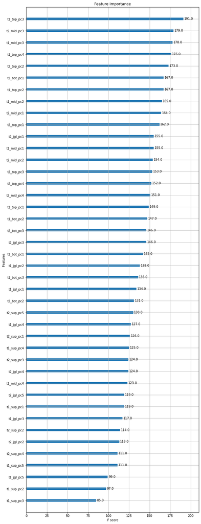

```python
# importance_type 기본값 weight
# 각 트리에서 데이터를 분리하는데 활용된 횟수(해당 피쳐가 얼마나 자주 쓰였는지)
plot_importance(model)
plt.rcParams['figure.figsize'] = [10, 30]
plt.show()
```

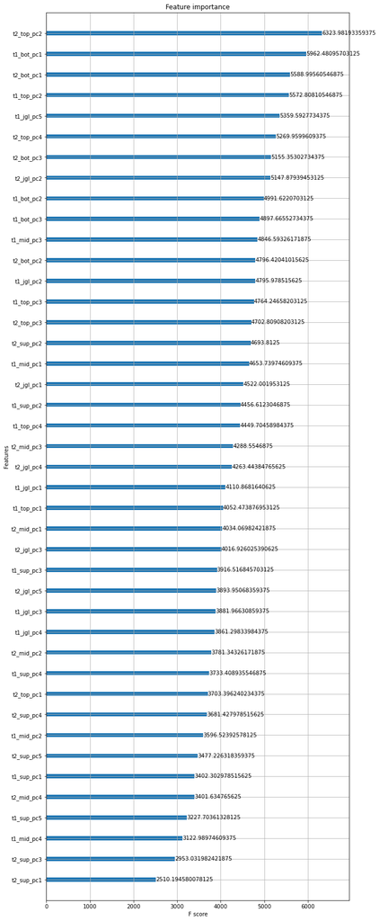

```python
# importance_type: cover
# 해당 변수에 의해 분리된 데이터의 평균적인 수
plot_importance(model, importance_type='cover')
plt.rcParams['figure.figsize'] = [10, 30]
plt.show()
```

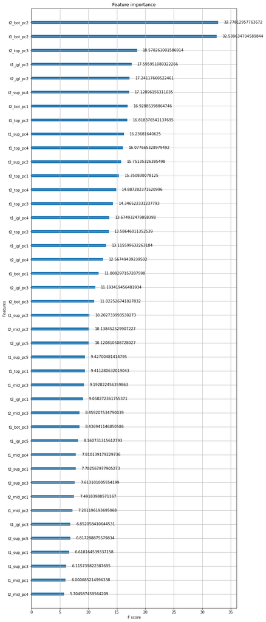

```python
# importance_type: gain
# 해당 피쳐로 분리하였을때 감소하는 loss값의 평균
plot_importance(model, importance_type='gain')
plt.rcParams['figure.figsize'] = [10, 30]
plt.show()
```

plot_importance는 총 3가지 관점에서 각 피쳐별 중요도를 산정하여 시각화해준다. 데이터의 의미나 분석의 목적에 따라 다르겠지만, 이번 분석의 핵심 목표는 '특정 포지션에 어떤 챔피언을 선택'하는가에 따른 승리여부의 변화를 확인하는 것이기 때문에, importance_type을 gain으로 선택하는것이 가장 합리적이라 판단하였다.

feature importance의 값이 상위권에 있는 몇몇 피쳐를 고른 후 해당 피쳐의 값을 결정한 pca모델의 고유벡터를 확인하여 게임의 승패에 관여하는 요소들이 어떤것이 있는지 확인해 보고자 한다. 살펴볼 피쳐명은 다음과 같다.

- bot_pc2
- jgl_pc2
- top_pc3

또한 피쳐 중요도의 상위권에 탑, 정글, 원딜이 위치하고 하위권에 미드, 서폿이 위치하는것을 확인 할 수 있다. 이는 위 세 라인들이 챔피언 픽에 의한 영향을 많이 받는 라인이라고 해석할 수 있으며, 미드와 서폿은 상대적으로 픽에 의한 게임구도의 변화가 크지 않은 라인이라 생각 할 수 있다.

#### 1. bot_pc2

```python
# 바텀(원딜) 분석에 사용된 컬럼명
with open("cols_bot.pickle","rb") as fr:
    cols_bot = pickle.load(fr)
cols_bot
```

```
Index(['gameDuration', 'assists', 'damageDealtToTurrets',
       'damageSelfMitigated', 'deaths', 'kills', 'magicDamageDealtToChampions',
       'physicalDamageDealtToChampions', 'timeCCingOthers',
       'totalDamageDealtToChampions', 'totalDamageTaken', 'totalMinionsKilled',
       'trueDamageDealtToChampions'],
      dtype='object')
```

```python
with open("pca_bot.pickle","rb") as fr:
    pca_bot = pickle.load(fr)
pca_bot.components_
```

```
array([[ 0.34808823,  0.06692046,  0.18114924,  0.33854508,  0.12014926,
         0.32172932,  0.15397137,  0.36920729,  0.1156925 ,  0.41730992,
         0.36133722,  0.26505276,  0.24619449],
       [ 0.20533389,  0.03746649, -0.47204859,  0.26718237,  0.56756444,
        -0.31171165,  0.03227202, -0.18782124,  0.09399546, -0.15777201,
         0.37638522, -0.14238042, -0.10459899],
       [ 0.00427298,  0.54067596,  0.10379109,  0.02702204, -0.18253449,
        -0.03275363,  0.57951382, -0.22260026,  0.45061608,  0.04261087,
        -0.06101884, -0.11553764, -0.23329574]])
```

```python
# 보기 좋게 DataFrame으로 정리
pd.DataFrame(data={'col':cols_bot, 'bot_pc2':pca_bot.components_[1]}) # bot_pc2
```

|  | col | bot_pc2 |
| --- | --- | --- |
| 0 | gameDuration | 0.205334 |
| 1 | assists | 0.037466 |
| 2 | damageDealtToTurrets | -0.472049 |
| 3 | damageSelfMitigated | 0.267182 |
| 4 | deaths | 0.567564 |
| 5 | kills | -0.311712 |
| 6 | magicDamageDealtToChampions | 0.032272 |
| 7 | physicalDamageDealtToChampions | -0.187821 |
| 8 | timeCCingOthers | 0.093995 |
| 9 | totalDamageDealtToChampions | -0.157772 |
| 10 | totalDamageTaken | 0.376385 |
| 11 | totalMinionsKilled | -0.142380 |
| 12 | trueDamageDealtToChampions | -0.104599 |

bot_pc2에 영향을 많이 주는 변수는 다음과 같다.

- deaths
- totalDamageTaken
- damageDealtToTurrets
- kills

위의 내용을 해석해보자면, 바텀 챔피언을 선택할 때 중요하게 고려되어야 하는 요소는 다음과 같다.

1. 생존성(deaths, totalDamageTaken)
2. 포탑 철거 능력(damageDealtToTurrets)
3. 킬캐치능력(kills)

이는 일반적인 게임에서 원딜 챔피언들에게 요구되는 능력과 일치한다.

pca결과의 bot_pc2값으로 주류픽 챔피언을 정렬한 결과는 아래와 같다.

```python
with open("label_bot.pickle","rb") as fr:
    label_bot = pickle.load(fr)
bot_major = label_bot[label_bot['bot_비주류']==0].index
bot_major # 주류 챔피언 리스트
```

```
Index(['Aphelios', 'Ashe', 'Caitlyn', 'Draven', 'Ezreal', 'Jhin', 'Jinx',
       'Kaisa', 'Kalista', 'KogMaw', 'Lucian', 'MissFortune', 'Nilah',
       'Samira', 'Sivir', 'Tristana', 'Twitch', 'Varus', 'Vayne', 'Xayah',
       'Yasuo', 'Zeri', 'Ziggs'],
      dtype='object')
```

```python
with open("label_bot2.pickle","rb") as fr:
    label_bot2 = pickle.load(fr)
# bot_pc2값으로 정렬
label_bot2.loc[bot_major].sort_values(by='bot_pc2',ascending=False)
```

|  | bot_pc1 | bot_pc2 | bot_pc3 |
| --- | --- | --- | --- |
| Yasuo | 0.628396 | 1.460562 | 0.257067 |
| Ashe | -0.179999 | 0.594197 | 1.236548 |
| Nilah | 0.288245 | 0.474775 | -0.665960 |
| KogMaw | 0.788903 | 0.388726 | 1.086617 |
| Zeri | 0.059728 | 0.342432 | 0.836099 |
| Samira | 0.402769 | 0.338832 | -0.517143 |
| Kalista | 0.191404 | 0.308131 | -0.207156 |
| Varus | 0.029887 | 0.300126 | 0.849472 |
| Draven | 0.271102 | 0.088793 | -0.597266 |
| Aphelios | 0.022002 | 0.080231 | -0.146689 |
| Jhin | -0.479931 | -0.039642 | 0.577600 |
| Vayne | 0.444318 | -0.047463 | -1.026167 |
| Twitch | 0.304290 | -0.098765 | -0.768793 |
| Ezreal | -0.064448 | -0.120370 | 0.251915 |
| Lucian | -0.076940 | -0.123363 | -0.378755 |
| Xayah | -0.171078 | -0.150830 | -0.019010 |
| Caitlyn | -0.198716 | -0.182503 | -0.047347 |
| Jinx | -0.145374 | -0.221360 | -0.157697 |
| MissFortune | 0.015991 | -0.247132 | -0.385745 |
| Kaisa | -0.008943 | -0.258798 | -0.225118 |
| Sivir | -0.171145 | -0.456403 | -1.180847 |
| Tristana | -0.006609 | -0.513175 | -0.503054 |
| Ziggs | 0.310666 | -1.219165 | 3.959623 |

pc2의 값으로 정렬된 챔피언 목록을 확인해보면, 앞서 언급한 세가지 기준으로 챔피언들이 구분됨을 확인 할 수 있다.

#### 2. jgl_pc2

```python
# 바텀(원딜) 분석에 사용된 컬럼명
with open("cols_jgl.pickle","rb") as fr:
    cols_jgl = pickle.load(fr)
cols_jgl
```

```
Index(['gameDuration', 'assists', 'damageDealtToObjectives',
       'damageSelfMitigated', 'deaths', 'dragonKills', 'kills',
       'magicDamageDealtToChampions', 'neutralMinionsKilled',
       'physicalDamageDealtToChampions', 'timeCCingOthers',
       'totalDamageDealtToChampions', 'totalDamageTaken',
       'trueDamageDealtToChampions'],
      dtype='object')
```

```python
with open("pca_jgl.pickle","rb") as fr:
    pca_jgl = pickle.load(fr)
pca_jgl.components_
```

```
array([[ 0.36271738,  0.08220461,  0.27468814,  0.31386605,  0.0672728 ,
         0.20514512,  0.32462736,  0.11335467,  0.29060462,  0.25905527,
         0.10714482,  0.41157448,  0.36371413,  0.24113993],
       [ 0.22854057,  0.00305764, -0.4360706 ,  0.23366622,  0.52945815,
        -0.40482174, -0.17201203,  0.03486864, -0.27894805, -0.02863508,
         0.17646976,  0.00889729,  0.34338368,  0.01505907],
       [ 0.1101106 ,  0.08636923,  0.01292942, -0.00546413, -0.07595881,
         0.05769772, -0.09037333,  0.72578894,  0.11974104, -0.63776842,
         0.0490124 ,  0.06231116,  0.03338655, -0.08773406],
       [-0.19489583, -0.23244528, -0.11384704, -0.35443673,  0.12800927,
        -0.30242586,  0.40800819,  0.24925439, -0.16116075,  0.03743771,
        -0.25708467,  0.36403136, -0.17005761,  0.42195584],
       [-0.25501326,  0.39493166, -0.14144456,  0.0521786 , -0.30101147,
        -0.09533328,  0.27377884,  0.0626745 , -0.25394586,  0.08115681,
         0.68776453,  0.13483328, -0.12182894, -0.02390567]])
```

```python
# 보기 좋게 DataFrame으로 정리
pd.DataFrame(data={'col':cols_jgl, 'jgl_pc2':pca_jgl.components_[1]}) # bot_pc2
```

|  | col | jgl_pc2 |
| --- | --- | --- |
| 0 | gameDuration | 0.228541 |
| 1 | assists | 0.003058 |
| 2 | damageDealtToObjectives | -0.436071 |
| 3 | damageSelfMitigated | 0.233666 |
| 4 | deaths | 0.529458 |
| 5 | dragonKills | -0.404822 |
| 6 | kills | -0.172012 |
| 7 | magicDamageDealtToChampions | 0.034869 |
| 8 | neutralMinionsKilled | -0.278948 |
| 9 | physicalDamageDealtToChampions | -0.028635 |
| 10 | timeCCingOthers | 0.176470 |
| 11 | totalDamageDealtToChampions | 0.008897 |
| 12 | totalDamageTaken | 0.343384 |
| 13 | trueDamageDealtToChampions | 0.015059 |

jgl_pc2에 영향을 많이 주는 변수는 다음과 같다.

- damageDealtToObjectives
- deaths
- dragonKills
- neutralMinionsKilled
- totalDamageTaken

위의 내용을 해석해보자면, 정글 챔피언을 선택할 때 중요하게 고려되어야 하는 요소는 다음과 같다.

1. 생존성(deaths, totalDamageTaken)
2. 오브젝트 컨트롤 능력(dragonKills, damageDealtToObjectives)
3. 정글링 능력(neutralMinionsKilled)

앞선 원딜의 경우와 마찬가지로, 이는 일반적인 게임에서 정글 챔피언들에게 요구되는 능력들과 일치한다.

pca결과의 jgl_pc2값으로 주류픽 챔피언을 정렬한 결과는 아래와 같다.

```python
with open("label_jgl.pickle","rb") as fr:
    label_jgl = pickle.load(fr)
jgl_major = label_jgl[label_jgl['jgl_비주류']==0].index
jgl_major # 주류 챔피언 리스트
```

```
Index(['Amumu', 'Belveth', 'Diana', 'Ekko', 'Elise', 'Evelynn', 'FiddleSticks',
       'Gragas', 'Graves', 'Hecarim', 'JarvanIV', 'Karthus', 'Kayn', 'Khazix',
       'Kindred', 'LeeSin', 'Lillia', 'MasterYi', 'MonkeyKing', 'Nidalee',
       'Nocturne', 'Nunu', 'Pantheon', 'Poppy', 'Qiyana', 'Rammus', 'RekSai',
       'Rengar', 'Sejuani', 'Shaco', 'Shyvana', 'Taliyah', 'Talon', 'Trundle',
       'Udyr', 'Vi', 'Viego', 'Volibear', 'Warwick', 'XinZhao', 'Zac', 'Zed',
       'Maokai', 'Mordekaiser', 'Jax', 'Twitch', 'Skarner'],
      dtype='object')
```

```python
with open("label_jgl2.pickle","rb") as fr:
    label_jgl2 = pickle.load(fr)
# jgl_pc2값으로 정렬
label_jgl2.loc[jgl_major].sort_values(by='jgl_pc2',ascending=False)
```

|  | jgl_pc1 | jgl_pc2 | jgl_pc3 | jgl_pc4 | jgl_pc5 |
| --- | --- | --- | --- | --- | --- |
| Rammus | -0.469848 | 1.251431 | 1.063608 | -0.991237 | 0.894377 |
| Maokai | -0.251607 | 1.070248 | 1.397905 | -0.954734 | 1.110999 |
| Nocturne | 0.623441 | 1.030835 | -0.440841 | -2.016449 | 4.222125 |
| Zac | -0.259640 | 0.942178 | 1.369923 | -0.808424 | 0.788273 |
| Nunu | -0.480769 | 0.611175 | 1.122607 | -0.966896 | 0.303578 |
| Warwick | -0.003736 | 0.603536 | 0.488687 | -0.509678 | 0.097737 |
| Sejuani | -0.360224 | 0.528354 | 0.344460 | -1.008943 | 0.330979 |
| Volibear | -0.114460 | 0.451813 | 0.095036 | -1.129428 | 0.376648 |
| Amumu | -0.339675 | 0.438284 | 1.152365 | -0.213225 | 0.388852 |
| JarvanIV | -0.483540 | 0.369443 | -0.596019 | -0.735334 | 0.079511 |
| Poppy | -0.337911 | 0.365019 | -0.600249 | -0.604951 | 0.461342 |
| Skarner | -0.462899 | 0.318020 | 0.158711 | -1.316847 | 0.546090 |
| XinZhao | 0.092615 | 0.293852 | -0.811010 | -0.520273 | -0.047365 |
| FiddleSticks | -0.521712 | 0.270640 | 1.773104 | 0.123305 | 0.600628 |
| Kayn | 0.491663 | 0.250396 | -1.111495 | -0.115290 | -0.198624 |
| Gragas | -0.519706 | 0.217826 | 1.623741 | 0.185079 | 0.423268 |
| LeeSin | -0.150846 | 0.191198 | -0.527818 | -0.611901 | -0.074254 |
| Hecarim | 0.457712 | 0.181224 | -0.616744 | -0.331487 | -0.200878 |
| Trundle | 0.063656 | 0.180176 | -0.545665 | -0.610463 | -0.116082 |
| Lillia | 0.581404 | 0.179472 | 1.468271 | 1.543867 | 0.022383 |
| Udyr | 0.170706 | 0.110233 | 0.017887 | -0.603152 | -0.053463 |
| Vi | -0.204530 | 0.103318 | -0.845417 | -0.660798 | 0.133742 |
| Mordekaiser | 0.721354 | 0.078488 | 1.484381 | -0.005571 | -0.342399 |
| Ekko | 0.005896 | 0.017107 | 1.512419 | 0.546796 | -0.081961 |
| MonkeyKing | -0.161862 | 0.007579 | -0.560032 | -0.469986 | 0.097852 |
| Pantheon | -0.305232 | -0.047393 | -1.070743 | 0.113505 | 0.006046 |
| Twitch | 0.223363 | -0.056021 | -1.249759 | 1.797201 | -0.066430 |
| Elise | -0.919111 | -0.061598 | 1.369353 | 0.686332 | 0.176250 |
| Evelynn | -0.342787 | -0.097301 | 1.944184 | 1.275426 | -0.002226 |
| Viego | 0.084020 | -0.118592 | -0.628261 | -0.217910 | -0.197148 |
| Karthus | 0.824577 | -0.144520 | 2.911691 | 1.767063 | -0.214345 |
| RekSai | 0.002131 | -0.160628 | -0.974868 | 0.524942 | 0.066205 |
| Qiyana | 0.146516 | -0.163685 | -1.025476 | 0.418531 | 0.188451 |
| Jax | -0.109248 | -0.163862 | -0.419957 | -0.171682 | -0.158482 |
| Talon | 0.523678 | -0.244993 | -1.296375 | 0.380995 | -0.353586 |
| Taliyah | -0.441209 | -0.251056 | 1.944596 | 0.944657 | 0.302728 |
| Belveth | 0.409706 | -0.255919 | -0.580852 | 0.373316 | -0.222891 |
| Shaco | -0.553556 | -0.308545 | 0.242811 | 0.603407 | 0.264599 |
| Shyvana | 0.716741 | -0.325647 | 1.502929 | -0.292575 | -0.581966 |
| Rengar | 0.255415 | -0.332943 | -0.993686 | 0.298488 | -0.253499 |
| Nidalee | -0.362684 | -0.334330 | 1.697786 | 0.668047 | -0.585587 |
| MasterYi | 0.722487 | -0.422812 | -1.042696 | 1.558253 | -0.715172 |
| Zed | 0.040662 | -0.425962 | -1.140029 | 0.557872 | -0.324102 |
| Diana | 0.060443 | -0.444095 | 1.525494 | 0.175555 | -0.485263 |
| Kindred | 0.178768 | -0.587934 | -0.738529 | 0.866534 | -0.574271 |
| Khazix | 0.247769 | -0.619015 | -1.053541 | 0.289580 | -0.407376 |
| Graves | 0.065142 | -0.726905 | -1.034056 | 0.076725 | -0.099828 |

jgl_pc2값으로 정렬한 챔피언들을 살펴보면, 역시나 비슷한 성향의 챔피언들끼리 모여있는것을 확인 할 수 있다.

#### 3. top_pc3

```python
# 탑 분석에 사용된 컬럼명
with open("cols_top.pickle","rb") as fr:
    cols_top = pickle.load(fr)
cols_top
```

```
Index(['gameDuration', 'assists', 'damageDealtToTurrets',
       'damageSelfMitigated', 'deaths', 'kills', 'magicDamageDealtToChampions',
       'neutralMinionsKilled', 'physicalDamageDealtToChampions',
       'timeCCingOthers', 'totalDamageDealtToChampions', 'totalDamageTaken',
       'totalMinionsKilled', 'trueDamageDealtToChampions'],
      dtype='object')
```

```python
with open("pca_top.pickle","rb") as fr:
    pca_top = pickle.load(fr)
pca_top.components_
```

```
array([[ 0.36357987,  0.06200705,  0.20860175,  0.33503184,  0.10914449,
         0.31483172,  0.08603159,  0.2061282 ,  0.27893752,  0.13993019,
         0.41787102,  0.3780272 ,  0.28961412,  0.22022327],
       [ 0.20471684,  0.09403439, -0.38954049,  0.26484647,  0.20101153,
        -0.19396376,  0.42966295, -0.21114592, -0.36357577,  0.39822166,
        -0.0098776 ,  0.25500184, -0.15147913, -0.20323731],
       [-0.08766141,  0.1242028 ,  0.18951643, -0.15287779, -0.53930444,
         0.24209175,  0.54199288,  0.1650601 , -0.33192265,  0.09644297,
         0.17147969, -0.24984239,  0.18053117, -0.05701173],
       [-0.2843274 ,  0.16571249,  0.03808505,  0.28225112, -0.40823656,
         0.223953  , -0.26333439, -0.25903895,  0.29664815,  0.51031532,
         0.00191183,  0.00256379, -0.30818496, -0.11795282]])
```

```python
# 보기 좋게 DataFrame으로 정리
pd.DataFrame(data={'col':cols_top, 'top_pc3':pca_top.components_[2]}) # top_pc3
```

|  | col | top_pc3 |
| --- | --- | --- |
| 0 | gameDuration | -0.087661 |
| 1 | assists | 0.124203 |
| 2 | damageDealtToTurrets | 0.189516 |
| 3 | damageSelfMitigated | -0.152878 |
| 4 | deaths | -0.539304 |
| 5 | kills | 0.242092 |
| 6 | magicDamageDealtToChampions | 0.541993 |
| 7 | neutralMinionsKilled | 0.165060 |
| 8 | physicalDamageDealtToChampions | -0.331923 |
| 9 | timeCCingOthers | 0.096443 |
| 10 | totalDamageDealtToChampions | 0.171480 |
| 11 | totalDamageTaken | -0.249842 |
| 12 | totalMinionsKilled | 0.180531 |
| 13 | trueDamageDealtToChampions | -0.057012 |

top_pc3에 영향을 많이 주는 변수는 다음과 같다.

- deaths
- magicDamageDealtToChampions
- physicalDamageDealtToChampions

위의 내용을 해석해보자면, 탑 챔피언을 선택할 때 중요하게 고려되어야 하는 요소는 다음과 같다.

1. 생존성(deaths)
2. 물리/마법 데미지 비율(magicDamageDealtToChampions, physicalDamageDealtToChampions)

마찬가지로, 탑 챔피언 선택에 있어서 주로 고려되는 요소들이라 볼 수 있다.

pca결과의 top_pc3값으로 주류픽 챔피언을 정렬한 결과는 아래와 같다.

```python
with open("label_top.pickle","rb") as fr:
    label_top = pickle.load(fr)
top_major = label_top[label_top['top_minor']==0].index
top_major # 주류 챔피언 리스트
```

```
Index(['Aatrox', 'Darius', 'Gangplank', 'Fiora', 'Renekton', 'Irelia', 'Gnar',
       'Camille', 'Sett', 'Mordekaiser', 'Jayce', 'Yone', 'Ornn', 'Jax',
       'Akali', 'Gwen', 'Shen', 'Malphite', 'Garen', 'Kayle', 'Gragas',
       'Teemo', 'Shyvana', 'Maokai', 'Volibear', 'Sejuani', 'Vayne', 'Riven',
       'Illaoi', 'Rumble', 'Sylas', 'Lillia', 'Udyr', 'Kennen', 'Nasus',
       'Olaf', 'Yorick', 'Poppy', 'Warwick', 'DrMundo', 'Vladimir', 'Rengar',
       'Zac', 'Sion', 'Tryndamere', 'Kled', 'Yasuo', 'TahmKench', 'Singed',
       'Quinn', 'Swain', 'MonkeyKing', 'Heimerdinger', 'Ryze', 'Viktor',
       'Urgot', 'Kayn', 'Trundle', 'Kalista', 'Graves', 'Lucian', 'Chogath',
       'Akshan', 'Pantheon', 'Cassiopeia', 'XinZhao'],
      dtype='object')
```

```python
with open("label_top2.pickle","rb") as fr:
    label_top2 = pickle.load(fr)
# bot_pc2값으로 정렬
label_top2.loc[top_major].sort_values(by='top_pc3',ascending=False)
```

|  | top_pc1 | top_pc2 | top_pc3 | top_pc4 |
| --- | --- | --- | --- | --- |
| Viktor | -0.568784 | 0.950225 | 1.970458 | -1.198551 |
| Heimerdinger | -0.756614 | 0.992508 | 1.894378 | -1.315362 |
| Cassiopeia | -0.282342 | 1.332375 | 1.714267 | -0.893932 |
| Teemo | -0.094699 | 0.635463 | 1.575419 | -0.663229 |
| Ryze | -0.673457 | 0.976683 | 1.467989 | -0.991536 |
| ... | ... | ... | ... | ... |
| Sett | 0.538967 | -0.557622 | -0.858000 | 0.616791 |
| Aatrox | 0.137657 | -0.457733 | -0.976063 | 0.609607 |
| Kled | 0.294892 | -0.618771 | -0.985726 | 0.468931 |
| Kayn | 0.473184 | -0.736311 | -1.055769 | 0.292833 |
| Illaoi | 0.813432 | -1.083524 | -1.198381 | -0.080472 |

66 rows × 4 columns

pc3의 값으로 정렬된 챔피언 목록을 확인해보면, 앞서 언급한 기준들로 챔피언들이 구분됨을 확인 할 수 있다.

#### 모델의 예측 확률

```python
# 예측결과를 확률로 반환
pred_prob = model.predict_proba(valid_x)
pred_prob[:5] # 0(패배)일 확률, 1(승리)일 확률 리스트로 반환
```

```
array([[0.14397365, 0.85602635],
       [0.41540635, 0.58459365],
       [0.6211531 , 0.37884688],
       [0.55276334, 0.44723663],
       [0.05856562, 0.9414344 ]], dtype=float32)
```

```python
valid_y[:5] # 실제 결과
```

```
array([1, 1, 1, 1, 1])
```

- 1,5번 게임은 모델이 비교적 강하게 확신하였고, 예측결과가 들어맞음
- 2,4번 게임은 모델이 판단을 어려워하였다.
- 3번 게임은 모델이 패배할것을 예측하였으나, 실제로는 승리함

```python
# 모델이 70%이상의 확률로 승부를 예측한 게임 수 비율(%)
((pred_prob[:,0]>=0.7).mean()+(pred_prob[:,0]<=0.3).mean())*100
```

```
45.144879451448794
```

여전히 55%의 게임은 챔피언 조합만 가지고는 승부예측이 어려운 측면이 있다. 그러나 나머지 45%게임은 챔피언 조합 구성 단계에서 이미 어느정도 승부의 향방이 결정된다고 볼 수 있겠다. 이는 매우 큰 수치로, 게임내에서 챔피언 조합만 잘 구성해도 두 게임중 한 게임은 높은 확률로 승리를 챙길 수 있다는 의미이다.

### 결론

트리기반 알고리즘에서 각 피쳐들은 분류의 기준이 될 뿐이지 피쳐값의 대소중 어느 방향이 더 승리에 유리한가에 대한 척도가 될 순 없다. 즉, 앞서 언급된 요소들이 더 뛰어난 챔피언이 유리한 것이 아닌, 해당 요소들로 챔피언을 구분하여 어떤 종류의 챔피언을 선택해야 하는지 판단의 기준이 될 것이다.

위의 피쳐별 importance를 시각화한 차트를 확인하면, 앞서 살펴본 3개의 피쳐 외에 다른 몇몇 피쳐들 역시 검토할 필요성이 있음을 알 수 있다. 이들을 꼼꼼히 살펴본다면 더 자세한 결론을 낼 수 있겠으나 같은 코드의 반복이며 또한 기존에 알지 못했던 새로운 사실을 알아내긴 힘들다고 생각하였다.

이번 분석의 가장 큰 의의는 기존 유저들이 경험적으로 알고있지만 쉽게 설명하기는 힘든 게임 내적 요소들의 상호작용이 승리에 미치는 영향력에 대해 데이터로 파악할 수 있었다는 점이다. 팀의 챔피언 구성은 승리에 절대적 영향은 미치지 못하지만, 충분히 의미있는 수준으로 영향을 끼친다는 점 역시 확인이 가능하였다.

#### 피드백 및 발전 가능성

- 데이터 수집 측면
  - 분석에 활용한 데이터는 6.1. 이후 플레티넘4 구간에서 발생한 10만건의 게임을 대상으로 진행되었다. 각 티어별로 데이터를 수집하여 분석을 한다면, 충분히 다른 결과가 나올 수 있을것이라 기대된다.
  - 또한 패치버젼에 따라 챔피언의 성능이 바뀌는 점을 고려한다면, 패치버전별로 데이터를 나누어 수집하면 좀 더 정교한 모델생성이 가능할 것이다.
- 다양한 변수 고려
  - 분석중에도 언급되었지만, 챔피언 구성만으로는 게임의 향방을 완벽히 예측 해 낼수 없다. 이에 대한 가장 큰 원인으로는 해당 챔피언을 플레이하는 유저의 실력이나 숙련도차이가 있겠다. 해당 유저가 해당 챔피언에 대해 갖는 숙련도를 수치화 할 수 있다면, 보다 정확한 모델 설계가 가능할 것이다.
- 모델 설계 측면
  - 다양한 측면에서 모델의 파라미터를 튜닝하였다면 좀 더 나은 결과를 기대해 볼 수 있다.
  - 널리 알려진 다른 종류의 알고리즘들을 더 적용시켜본다면 새로운 해석을 기대해 볼 수 있다.
- 모델 활용 방안
  - 결국 유저들의 관심사는, 주어진 상황에서 '어떤 챔피언을 선택해야 하는가'일 것이다.
  - 완성한 모델을 기반으로 주어진 상황에서 유저가 선택해야 하는 특정 포지션의 챔피언을 추천하고, 해당 챔피언을 선택하였을때의 기대승률을 예측하여 제공 할 수 있다.